# Examples of SVM

# Packages

```r
library("tidyverse")
library("e1071")
library("here")
here()
```

```
## [1] "C:/Users/bayanivb/Documents/Masters/Stat 218/SVM"
```

- *tidyverse* for data management
- *e1071* for SVM (an alternative package is the *kernlabs* package)

# Data Set

```r
cancer <- read_csv(file=here("breast cancer.csv"), col_types = cols(diagnosis = col_factor(levels = c("M", "B"))))
cancer
```

| id | diagnosis | radius_mean | texture_mean | perimeter_mean | area_mean | smoothness_mean | compactness_mean | concavity_mean | concave points_mean | symmetry_mean | fractal_dimension_mean | radius_se | texture_se | perimeter_se | area_se | smoothness_se | compactness_se | concavity_se | concave points_se | symmetry_se | fractal_dimension_se | radius_worst | texture_worst | perimeter_worst | area_worst | smoothness_worst | compactness_worst | concavity_worst | concave points_worst | … |
| --- | --- | --- | --- | --- | --- | --- | --- | --- | --- | --- | --- | --- | --- | --- | --- | --- | --- | --- | --- | --- | --- | --- | --- | --- | --- | --- | --- | --- | --- | --- |
| 842302 | M | 17.990 | 10.38 | 122.80 | 1001.0 | 0.11840 | 0.27760 | 0.3001000 | 0.147100 | 0.2419 | 0.07871 | 1.0950 | 0.9053 | 8.5890 | 153.400 | 0.006399 | 0.049040 | 0.0537300 | 0.015870 | 0.030030 | 0.0061930 | 25.380 | 17.33 | 184.60 | 2019.0 | 0.16220 | 0.66560 | 0.711900 | 0.265400 | … |
| 842517 | M | 20.570 | 17.77 | 132.90 | 1326.0 | 0.08474 | 0.07864 | 0.0869000 | 0.070170 | 0.1812 | 0.05667 | 0.5435 | 0.7339 | 3.3980 | 74.080 | 0.005225 | 0.013080 | 0.0186000 | 0.013400 | 0.013890 | 0.0035320 | 24.990 | 23.41 | 158.80 | 1956.0 | 0.12380 | 0.18660 | 0.241600 | 0.186000 | … |
| 84300903 | M | 19.690 | 21.25 | 130.00 | 1203.0 | 0.10960 | 0.15990 | 0.1974000 | 0.127900 | 0.2069 | 0.05999 | 0.7456 | 0.7869 | 4.5850 | 94.030 | 0.006150 | 0.040060 | 0.0383200 | 0.020580 | 0.022500 | 0.0045710 | 23.570 | 25.53 | 152.50 | 1709.0 | 0.14440 | 0.42450 | 0.450400 | 0.243000 | … |
| 84348301 | M | 11.420 | 20.38 | 77.58 | 386.1 | 0.14250 | 0.28390 | 0.2414000 | 0.105200 | 0.2597 | 0.09744 | 0.4956 | 1.1560 | 3.4450 | 27.230 | 0.009110 | 0.074580 | 0.0566100 | 0.018670 | 0.059630 | 0.0092080 | 14.910 | 26.50 | 98.87 | 567.7 | 0.20980 | 0.86630 | 0.686900 | 0.257500 | … |
| 84358402 | M | 20.290 | 14.34 | 135.10 | 1297.0 | 0.10030 | 0.13280 | 0.1980000 | 0.104300 | 0.1809 | 0.05883 | 0.7572 | 0.7813 | 5.4380 | 94.440 | 0.011490 | 0.024610 | 0.0568800 | 0.018850 | 0.017560 | 0.0051150 | 22.540 | 16.67 | 152.20 | 1575.0 | 0.13740 | 0.20500 | 0.400000 | 0.162500 | … |
| 843786 | M | 12.450 | 15.70 | 82.57 | 477.1 | 0.12780 | 0.17000 | 0.1578000 | 0.080890 | 0.2087 | 0.07613 | 0.3345 | 0.8902 | 2.2170 | 27.190 | 0.007510 | 0.033450 | 0.0367200 | 0.011370 | 0.021650 | 0.0050820 | 15.470 | 23.75 | 103.40 | 741.6 | 0.17910 | 0.52490 | 0.535500 | 0.174100 | … |
| 844359 | M | 18.250 | 19.98 | 119.60 | 1040.0 | 0.09463 | 0.10900 | 0.1127000 | 0.074000 | 0.1794 | 0.05742 | 0.4467 | 0.7732 | 3.1800 | 53.910 | 0.004314 | 0.013820 | 0.0225400 | 0.010390 | 0.013690 | 0.0021790 | 22.880 | 27.66 | 153.20 | 1606.0 | 0.14420 | 0.25760 | 0.378400 | 0.193200 | … |
| 84458202 | M | 13.710 | 20.83 | 90.20 | 577.9 | 0.11890 | 0.16450 | 0.0936600 | 0.059850 | 0.2196 | 0.07451 | 0.5835 | 1.3770 | 3.8560 | 50.960 | 0.008805 | 0.030290 | 0.0248800 | 0.014480 | 0.014860 | 0.0054120 | 17.060 | 28.14 | 110.60 | 897.0 | 0.16540 | 0.36820 | 0.267800 | 0.155600 | … |
| 844981 | M | 13.000 | 21.82 | 87.50 | 519.8 | 0.12730 | 0.19320 | 0.1859000 | 0.093530 | 0.2350 | 0.07389 | 0.3063 | 1.0020 | 2.4060 | 24.320 | 0.005731 | 0.035020 | 0.0355300 | 0.012260 | 0.021430 | 0.0037490 | 15.490 | 30.73 | 106.20 | 739.3 | 0.17030 | 0.54010 | 0.539000 | 0.206000 | … |
| 84501001 | M | 12.460 | 24.04 | 83.97 | 475.9 | 0.11860 | 0.23960 | 0.2273000 | 0.085430 | 0.2030 | 0.08243 | 0.2976 | 1.5990 | 2.0390 | 23.940 | 0.007149 | 0.072170 | 0.0774300 | 0.014320 | 0.017890 | 0.0100800 | 15.090 | 40.68 | 97.65 | 711.4 | 0.18530 | 1.05800 | 1.105000 | 0.221000 | … |

[output cut: 559 more lines]

- this is from UC Irvine public domain data sets - Breast Cancer (Diagnosis) data set. Features are computed from a digitized image of a fine needle aspirate (FNA) of a breast mass. They describe characteristics of the cell nuclei present in the image.

Ten real-valued features are computed for each cell nucleus:

1. radius (mean of distances from center to points on the perimeter)
2. texture (standard deviation of gray-scale values)
3. perimeter
4. area
5. smoothness (local variation in radius lengths)
6. compactness (perimeter^2 / area - 1.0)
7. concavity (severity of concave portions of the contour)
8. concave points (number of concave portions of the contour)
9. symmetry
10. fractal dimension (“coastline approximation” - 1)

# Binary Classification Example

## Basic Example

Below, we fit a linear SVM and the tuning parameter *cost* is equal to 1.

```r
svm_linear <- svm(formula = diagnosis ~ ., data = select(cancer, -id), scale = T,
                  type = "C-classification", kernel = "linear", cost = 1)

summary(svm_linear)
```

```
##
## Call:
## svm(formula = diagnosis ~ ., data = select(cancer, -id), type = "C-classification",
##     kernel = "linear", cost = 1, scale = T)
##
##
## Parameters:
##    SVM-Type:  C-classification
##  SVM-Kernel:  linear
##        cost:  1
##
## Number of Support Vectors:  40
##
##  ( 21 19 )
##
##
## Number of Classes:  2
##
## Levels:
##  M B
```

We can predict values using predict() function. It can be applied on new samples by setting the *newdata =* option. In this illustration, we only implemented in-sample prediction.

```r
pred_class <- predict(svm_linear, newdata = cancer)
table("observed" = cancer$diagnosis, "predicted" = pred_class)
```

```
##         predicted
## observed   M   B
##        M 207   5
##        B   2 355
```

Also, there is an option to identify the support vectors in your data. The index part of the output gives the index/position of the support vectors in the data.

```r
svm_linear$index
```

```
##  [1]  14  39  41  74  87  92 100 136 185 191 195 198 206 214 216 256 264 298 490
## [20] 515 537  69  82  90 158 209 226 239 292 341 364 397 414 456 467 470 492 527
## [39] 542 543
```

## Optimizing the Tuning Parameter Cost

The result of SVM depends on how well the hyperparameters were tuned. The package *e1071* has a function *tune* which allows us to set multiple hyperparameter values. Then, the function will give you the “best” among the combinations given.

```r
svm_linear_tuned <- tune(method = 'svm', train.x = diagnosis ~ ., data = select(cancer, -id),
                         ranges = list('cost' = seq(0.5, 10, 0.5)),
                         tunecontrol = tune.control(sampling = "cross"))
```

```r
svm_linear_tuned
```

```
##
## Parameter tuning of 'svm':
##
## - sampling method: 10-fold cross validation
##
## - best parameters:
##  cost
##   2.5
##
## - best performance: 0.01757519
```

## Using the Kernel Trick

Let’s try using kernels. It is important that you know the additional hyperparameters that the kernel function will introduce. For example, the radial basis function (RBF) introduces one hyperparameter. It is a scale parameter. It is commonly denoted as $\sigma^2$, but all hyperparameters in *svm()* will be passed to the *gamma =* option. Since the hyperparameter in RBF is a scale parameter, there is no point in trying negative values.

```r
svm_rbf_tuned <- tune(method = 'svm', train.x = diagnosis ~ ., data = select(cancer, -id),
                         ranges = list('cost' = seq(1, 10, 1), "kernel" = "radial",
                                       "gamma" = seq(0.25,2, 0.25)),
                         tunecontrol = tune.control(sampling = "cross"))
```

```r
svm_rbf_tuned
```

```
##
## Parameter tuning of 'svm':
##
## - sampling method: 10-fold cross validation
##
## - best parameters:
##  cost kernel gamma
##     4 radial  0.25
##
## - best performance: 0.06867168
```

```r
svm_rbf <- svm(formula = diagnosis ~ ., data = select(cancer, -id), scale = T,
                  type = "C-classification", kernel = "radial", cost = 2, gamma = 0.25)
```

```r
summary(svm_rbf)
```

```
##
## Call:
## svm(formula = diagnosis ~ ., data = select(cancer, -id), type = "C-classification",
##     kernel = "radial", cost = 2, gamma = 0.25, scale = T)
##
##
## Parameters:
##    SVM-Type:  C-classification
##  SVM-Kernel:  radial
##        cost:  2
##
## Number of Support Vectors:  387
##
##  ( 185 202 )
##
##
## Number of Classes:  2
##
## Levels:
##  M B
```

```r
pred_class <- predict(svm_rbf, newdata = cancer)
table("observed" = cancer$diagnosis, "predicted" = pred_class)
```

```
##         predicted
## observed   M   B
##        M 211   1
##        B   0 357
```

It is difficult to know which kernel function will give the best result before analysis. And so, the best way to know is to try and experiment on different kernel functions available.

Exploring the use of the polynomials as another option for the kernel functions, in this example, I used a polynomial kernel with a degree =2 which I will compare with the performance of the svm using the rbf kernel

```r
svm_polynomial_tuned <- tune(method = 'svm', train.x = diagnosis ~ ., data = select(cancer, -id),
                         ranges = list('cost' = seq(1, 10, 1), "kernel" = "polynomial",degree=2,
                                       "gamma" = seq(0.25,2, 0.25)),
                         tunecontrol = tune.control(sampling = "cross"))
```

```r
svm_polynomial_tuned
```

```
##
## Parameter tuning of 'svm':
##
## - sampling method: 10-fold cross validation
##
## - best parameters:
##  cost     kernel degree gamma
##     3 polynomial      2  0.25
##
## - best performance: 0.1194236
```

```r
svm_polynomial <- svm(formula = diagnosis ~ ., data = select(cancer, -id), scale = T,
                  type = "C-classification", kernel = "polynomial", degree = 2, gamma = 0.25)
```

```r
summary(svm_polynomial)
```

```
##
## Call:
## svm(formula = diagnosis ~ ., data = select(cancer, -id), type = "C-classification",
##     kernel = "polynomial", degree = 2, gamma = 0.25, scale = T)
##
##
## Parameters:
##    SVM-Type:  C-classification
##  SVM-Kernel:  polynomial
##        cost:  1
##      degree:  2
##      coef.0:  0
##
## Number of Support Vectors:  194
##
##  ( 86 108 )
##
##
## Number of Classes:  2
##
## Levels:
##  M B
```

```r
pred_class_polynomial <- predict(svm_polynomial, newdata = cancer)
table("observed" = cancer$diagnosis, "predicted" = pred_class)
```

```
##         predicted
## observed   M   B
##        M 211   1
##        B   0 357
```

# Multi-class Example

We will use the digits handwriting detection data set, popularly known as MNIST data set. Sampling was applied for demonstration purposes.

```r
set.seed(1234)
num_labels = c("0","1","2","3","4","5","6","7","8","9")
mnist_train <- read_csv(file=here("mnist_train.csv"), col_types = cols(label = col_factor(levels = num_labels))) %>%
                  group_by(label) %>%
                  sample_n(200) %>%
                  ungroup()
mnist_test <- read_csv(file=here("mnist_test.csv"), col_types = cols(label = col_factor(levels = num_labels))) %>%
                  group_by(label) %>%
                  sample_n(100) %>%
                  ungroup()
```

```r
head(mnist_train)
```

| label | 1x1 | 1x2 | 1x3 | 1x4 | 1x5 | 1x6 | 1x7 | 1x8 | 1x9 | 1x10 | 1x11 | 1x12 | 1x13 | 1x14 | 1x15 | 1x16 | 1x17 | 1x18 | 1x19 | 1x20 | 1x21 | 1x22 | 1x23 | 1x24 | 1x25 | 1x26 | 1x27 | 1x28 | 2x1 | … |
| --- | --- | --- | --- | --- | --- | --- | --- | --- | --- | --- | --- | --- | --- | --- | --- | --- | --- | --- | --- | --- | --- | --- | --- | --- | --- | --- | --- | --- | --- | --- |
| 0 | 0 | 0 | 0 | 0 | 0 | 0 | 0 | 0 | 0 | 0 | 0 | 0 | 0 | 0 | 0 | 0 | 0 | 0 | 0 | 0 | 0 | 0 | 0 | 0 | 0 | 0 | 0 | 0 | 0 | … |
| 0 | 0 | 0 | 0 | 0 | 0 | 0 | 0 | 0 | 0 | 0 | 0 | 0 | 0 | 0 | 0 | 0 | 0 | 0 | 0 | 0 | 0 | 0 | 0 | 0 | 0 | 0 | 0 | 0 | 0 | … |
| 0 | 0 | 0 | 0 | 0 | 0 | 0 | 0 | 0 | 0 | 0 | 0 | 0 | 0 | 0 | 0 | 0 | 0 | 0 | 0 | 0 | 0 | 0 | 0 | 0 | 0 | 0 | 0 | 0 | 0 | … |
| 0 | 0 | 0 | 0 | 0 | 0 | 0 | 0 | 0 | 0 | 0 | 0 | 0 | 0 | 0 | 0 | 0 | 0 | 0 | 0 | 0 | 0 | 0 | 0 | 0 | 0 | 0 | 0 | 0 | 0 | … |
| 0 | 0 | 0 | 0 | 0 | 0 | 0 | 0 | 0 | 0 | 0 | 0 | 0 | 0 | 0 | 0 | 0 | 0 | 0 | 0 | 0 | 0 | 0 | 0 | 0 | 0 | 0 | 0 | 0 | 0 | … |
| 0 | 0 | 0 | 0 | 0 | 0 | 0 | 0 | 0 | 0 | 0 | 0 | 0 | 0 | 0 | 0 | 0 | 0 | 0 | 0 | 0 | 0 | 0 | 0 | 0 | 0 | 0 | 0 | 0 | 0 | … |

Sample images from the data:

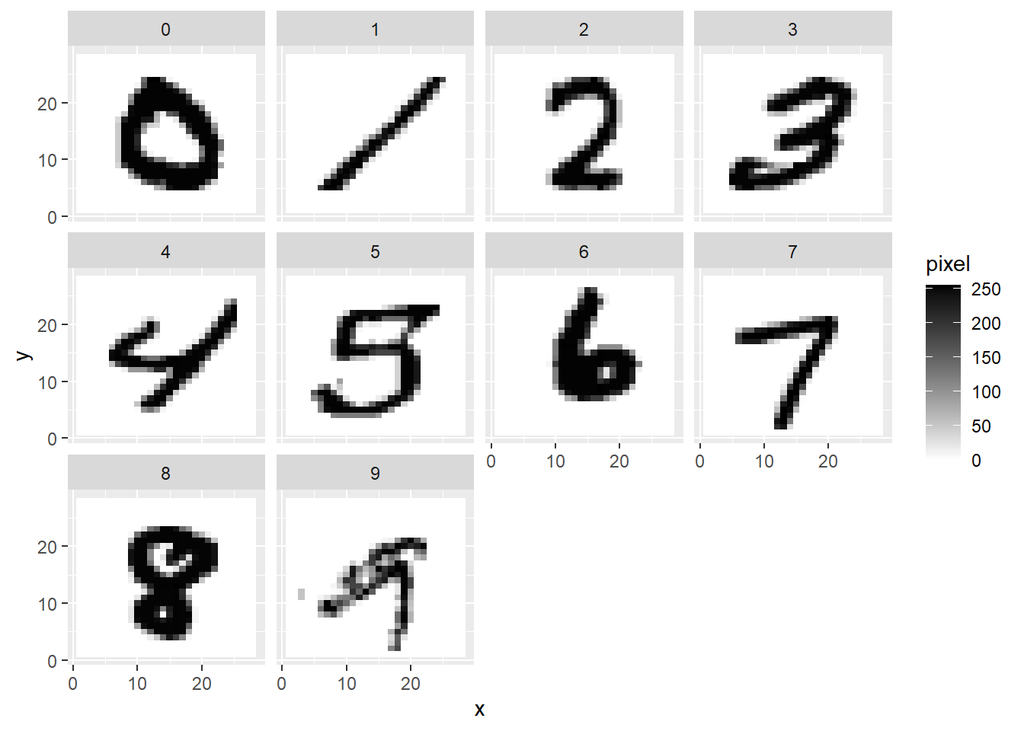

```r
mnist_test %>%
  group_by(label) %>%
  sample_n(1) %>%
  ungroup() %>%
  gather(`1x1`:`28x28`, key = "pos", value = "pixel") %>%
  mutate(y = 29 - as.numeric(str_extract(pos, pattern = "\\d+(?=x)")),
         x = as.numeric(str_extract(pos, pattern = "(?<=x)\\d+"))
         ) %>%
  ggplot(aes(x = x, y = y, fill = pixel)) +
  geom_tile(stat = "identity") +
  facet_wrap(. ~ label) +
  scale_fill_gradient(low = "white", high = "black")
```

```r
mnist_train <- mnist_train %>%
                  mutate_if(.predicate = is.numeric, .funs = function(x) x/225)

mnist_test  <- mnist_test %>%
                  mutate_if(.predicate = is.numeric, .funs = function(x) x/225)
```

## Straightforward SVM

```r
svm_mnist <- svm(formula = label ~ ., data = mnist_train, scale = F,
                  type = "C-classification", kernel = "radial", cost = 1, gamma = 1)

summary(svm_mnist)
```

```
##
## Call:
## svm(formula = label ~ ., data = mnist_train, type = "C-classification",
##     kernel = "radial", cost = 1, gamma = 1, scale = F)
##
##
## Parameters:
##    SVM-Type:  C-classification
##  SVM-Kernel:  radial
##        cost:  1
##
## Number of Support Vectors:  2000
##
##  ( 200 200 200 200 200 200 200 200 200 200 )
##
##
## Number of Classes:  10
##
## Levels:
##  0 1 2 3 4 5 6 7 8 9
```

```r
pred_label <- predict(svm_mnist, newdata = mnist_test)
```

```r
table("observed" = mnist_test$label, "predicted" = pred_label)
```

```
##         predicted
## observed   0   1   2   3   4   5   6   7   8   9
##        0   6   0  94   0   0   0   0   0   0   0
##        1   0  20  77   0   0   0   0   0   3   0
##        2   0   0 100   0   0   0   0   0   0   0
##        3   0   0  98   2   0   0   0   0   0   0
##        4   0   0  94   0   6   0   0   0   0   0
##        5   0   0 100   0   0   0   0   0   0   0
##        6   0   0  98   0   0   0   2   0   0   0
##        7   0   0  92   0   0   0   0   8   0   0
##        8   0   0 100   0   0   0   0   0   0   0
##        9   0   0  95   0   0   0   0   0   0   5
```

```r
mean(pred_label == mnist_test$label)
```

```
## [1] 0.149
```

# Regression Example

For the regression application, let’s apply SVR to the house price data set. SVR may result to a more robust prediction model of price (i.e., less sensitive to outliers).

```r
house_price <- read_rds(file=here("house_price.rds")) %>%
                mutate(log_price = log(price))
house_price
```

| price | bedrooms | bathrooms | sqft_living | sqft_lot | floors | waterfront | sqft_above | sqft_basement | house_age | renov | good_con | log_price |
| --- | --- | --- | --- | --- | --- | --- | --- | --- | --- | --- | --- | --- |
| 394250 | 3 | 2.00 | 2620 | 10107 | 1.0 | WITHOUT VIEW | 2620 | 0 | 32 | n | n | 12.88474 |
| 679000 | 4 | 2.50 | 3080 | 8451 | 1.0 | WITHOUT VIEW | 1540 | 1540 | 46 | n | n | 13.42838 |
| 560000 | 4 | 2.25 | 1950 | 9800 | 1.0 | WITHOUT VIEW | 1330 | 620 | 46 | n | n | 13.23569 |
| 220000 | 5 | 2.50 | 1760 | 10200 | 1.5 | WITHOUT VIEW | 1760 | 0 | 89 | n | n | 12.30138 |
| 485000 | 4 | 3.25 | 2820 | 6611 | 1.0 | WITHOUT VIEW | 1410 | 1410 | 56 | n | n | 13.09190 |
| 249900 | 3 | 2.50 | 1610 | 3517 | 2.0 | WITHOUT VIEW | 1610 | 0 | 9 | n | n | 12.42882 |
| 645000 | 3 | 2.00 | 2130 | 4000 | 2.0 | WITHOUT VIEW | 2130 | 0 | 106 | n | n | 13.37701 |
| 749950 | 4 | 2.50 | 2620 | 8312 | 2.0 | WITHOUT VIEW | 2620 | 0 | 25 | n | n | 13.52776 |
| 499000 | 4 | 2.50 | 2910 | 6479 | 2.0 | WITHOUT VIEW | 2910 | 0 | 8 | n | n | 13.12036 |
| 315000 | 3 | 1.00 | 970 | 6828 | 1.0 | WITHOUT VIEW | 970 | 0 | 86 | n | n | 12.66033 |

[output cut: 8636 more lines]

```r
svm_price <- svm(formula = log_price ~ bedrooms + bathrooms + sqft_living + sqft_lot + sqft_above + house_age,
                 data = house_price, scale = T, kernel = "linear",
                  type = "eps-regression", cost = 1, epsilon = 0.5)

summary(svm_price)
```

```
##
## Call:
## svm(formula = log_price ~ bedrooms + bathrooms + sqft_living + sqft_lot +
##     sqft_above + house_age, data = house_price, kernel = "linear",
##     type = "eps-regression", cost = 1, epsilon = 0.5, scale = T)
##
##
## Parameters:
##    SVM-Type:  eps-regression
##  SVM-Kernel:  linear
##        cost:  1
##       gamma:  0.1666667
##     epsilon:  0.5
##
##
## Number of Support Vectors:  4135
```

```r
pred_price <- exp(predict(svm_price, newdata = house_price))
mean(abs(pred_price - house_price$price)/house_price$price)
```

```
## [1] 0.3011555
```

Trying out different kernel types to see the effect on the performance,

For the RBF kernel,

```r
svm_price_rbf <- svm(formula = log_price ~ bedrooms + bathrooms + sqft_living + sqft_lot + sqft_above + house_age, data = house_price, scale = T, kernel = "radial", cost=2)

summary(svm_price_rbf)
```

```
##
## Call:
## svm(formula = log_price ~ bedrooms + bathrooms + sqft_living + sqft_lot +
##     sqft_above + house_age, data = house_price, kernel = "radial",
##     cost = 2, scale = T)
##
##
## Parameters:
##    SVM-Type:  eps-regression
##  SVM-Kernel:  radial
##        cost:  2
##       gamma:  0.1666667
##     epsilon:  0.1
##
##
## Number of Support Vectors:  7631
```

```r
pred_price_rbf <- exp(predict(svm_price_rbf, newdata = house_price))
mean(abs(pred_price_rbf - house_price$price)/house_price$price)
```

```
## [1] 0.2731824
```

Using the RBF kernel results in a lower error as compared to the linear kernel.

Exploring the use of the polynomial kernel,

```r
svm_price_polynomial <- svm(formula = log_price ~ bedrooms + bathrooms + sqft_living + sqft_lot + sqft_above + house_age, data = house_price, scale = T, kernel = "polynomial", degree=2)

summary(svm_price_polynomial)
```

```
##
## Call:
## svm(formula = log_price ~ bedrooms + bathrooms + sqft_living + sqft_lot +
##     sqft_above + house_age, data = house_price, kernel = "polynomial",
##     degree = 2, scale = T)
##
##
## Parameters:
##    SVM-Type:  eps-regression
##  SVM-Kernel:  polynomial
##        cost:  1
##      degree:  2
##       gamma:  0.1666667
##      coef.0:  0
##     epsilon:  0.1
##
##
## Number of Support Vectors:  7839
```

```r
pred_price_polynomial <- exp(predict(svm_price_polynomial, newdata = house_price))
mean(abs(pred_price_polynomial - house_price$price)/house_price$price)
```

```
## [1] 0.418732
```

Using the polynomial kernel is not recommended in this case since it results to a higher error versus the linear and RBF kernel models.